# Colorado temperature analysis

## Colorado spring temperature data

These data were originally part of the `fields` package’s `COmonthlyMet` dataset.

```r
rm(list = ls())
load("CO-temp-data.RData")
ls()
```

```
[1] "coords"      "elev"        "pred.coords" "pred.elev"   "temp"
```

Our goal is to create a complete prediction surface of minimum spring temperature with associated estimates of uncertainty.

We begin by loading the necessary packages.

```r
library(spBayes)
library(MBA)
library(geoR)
library(raster)
library(leaflet)
library(sp)
```

Next, set up a `leaflet` basemap to help visualize the data and model output. We’ll make heavy use of the pipe operator `%>%` in the leaflet code to reduce clutter.

```r
blue.red <- c("#2c7bb6", "#abd9e9", "#ffffbf", "#fdae61", "#d7191c")

base.map <- leaflet(width = "100%") %>%
    addProviderTiles("Stamen.Terrain", group = "Terrain") %>%
    addProviderTiles("Esri.WorldImagery", group = "Satellite") %>%
    addLayersControl(baseGroup = c("Terrain", "Satellite"), options = layersControlOptions(collapsed = FALSE))
```

Take a look at station locations and mean minimum spring temperatures across Colorado. This code below produces a clickable dynamic map.

```r
pal <- colorNumeric(blue.red, domain = temp)

base.map %>%
    addCircleMarkers(lng = coords[, 1], lat = coords[, 2], col = pal(temp), stroke = FALSE,
        radius = 5, fillOpacity = 0.9, popup = paste("Mean min temp:", round(temp,
            1))) %>%
    addLegend("bottomright", pal = pal, values = temp, opacity = 0.9, title = "Temperature C")
```

[interactive chart not shown]

### Fit a non-spatial regression

Consider the non-spatial regression and a little exploratory data analysis (EDA).

```r
lm.obj <- lm(temp ~ lon + lat, data = coords)
summary(lm.obj)
```

```
Call:
lm(formula = temp ~ lon + lat, data = coords)

Residuals:
    Min      1Q  Median      3Q     Max
-9.1462 -2.1591  0.6497  1.9584  8.1021

Coefficients:
            Estimate Std. Error t value Pr(>|t|)
(Intercept) 79.46995   12.28571   6.468 6.84e-10 ***
lon          0.63528    0.09277   6.848 8.13e-11 ***
lat         -0.35593    0.15576  -2.285   0.0233 *
---
Signif. codes:  0 '***' 0.001 '**' 0.01 '*' 0.05 '.' 0.1 ' ' 1

Residual standard error: 3.191 on 210 degrees of freedom
Multiple R-squared:  0.1873,    Adjusted R-squared:  0.1796
F-statistic:  24.2 on 2 and 210 DF,  p-value: 3.478e-10
```

We’ll reproject the geographic coordinates (i.e., longitude and latitude) to a coordinate system that provides more familiar distance units and reduces spatial distortion. Here we selected Universal Transverse Mercator (UTM) coordinate system (with km distance units).

```r
## Convert coords to spatial points and reproject.
coordinates(coords) <- ~lon + lat
proj4string(coords) <- "+proj=longlat +datum=WGS84"

coords.utm <- spTransform(coords, CRS("+proj=utm +zone=13 +ellps=WGS84 +datum=WGS84 +units=km +no_defs"))
coords.utm <- coordinates(coords.utm)

## Convert spatial points to matrix for later mapping.
coords <- coordinates(coords)
```

Next let’s take a look at the regression model residuals, assess their spatial independence, and start thinking about variogram and covariance parameters.

```r
d.max <- max(iDist(coords.utm))
d.max
```

```
[1] 841.6322
```

```r
v.temp <- variog(coords = coords.utm, data = temp, uvec = (seq(0, 0.75 * d.max, length = 20)))
```

```
variog: computing omnidirectional variogram
```

```r
v.resid <- variog(coords = coords.utm, data = resid(lm.obj), uvec = (seq(0, 0.75 *
    d.max, length = 20)))
```

```
variog: computing omnidirectional variogram
```

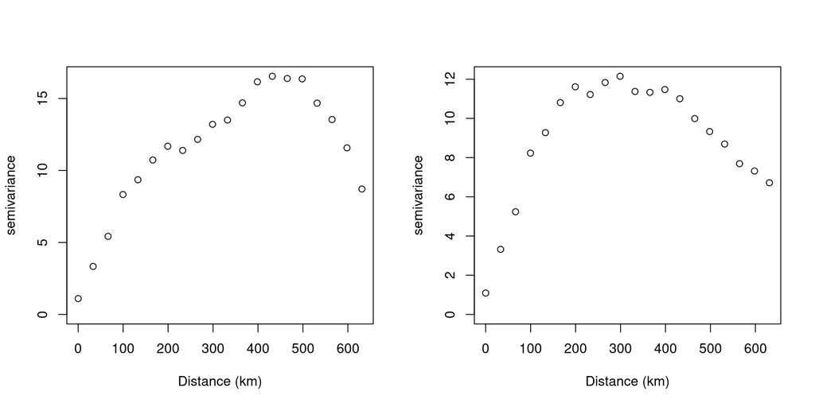

```r
par(mfrow = c(1, 2))
plot(v.temp, xlab = "Distance (km)")
plot(v.resid, xlab = "Distance (km)")
```

It is also very helpful to create an interpolated surface of the model residuals to further assess spatial structure and potentially identify missing covariates.

```r
resid.surf <- mba.surf(cbind(coords, resid(lm.obj)), no.X = 200, no.Y = 200, extend = TRUE,
    sp = TRUE)$xyz.est

proj4string(resid.surf) <- "+proj=longlat +datum=WGS84"

resid.surf <- raster(resid.surf)

pal <- colorNumeric(blue.red, values(resid.surf), na.color = "transparent")

base.map %>%
    addRasterImage(resid.surf, colors = pal, opacity = 0.75, group = "Regression residuals") %>%
    addLegend("bottomright", pal = pal, values = values(resid.surf), opacity = 0.75,
        title = "<center>Regression<br> residuals</center>") %>%
    addLayersControl(baseGroup = c("Terrain", "Satellite"), overlayGroups = c("Regression residuals"),
        options = layersControlOptions(collapsed = FALSE))
```

[interactive chart not shown]

### Fit some spatial regression models

There’s substantial evidence of residual spatial structure, so let’s fit some models with spatially-structured random effects. First we’ll fit the `bayesGeostatExact()` model then the `spLM()` model both from the `spBayes` package.

```r
n.samples <- 5000

n <- length(temp)
p <- 3  ##Intercept and spatial locations

phi <- 3/200
alpha <- 1/12  #tau^2/sigma^2

beta.prior.mean <- as.matrix(rep(0, times = p))
beta.prior.precision <- matrix(0, nrow = p, ncol = p)

## Assuming an inverse Gamma prior on sigma^2
sigma.sq.prior.shape <- 2
sigma.sq.prior.rate <- 1/12  ##1/scale

m.exact <- bayesGeostatExact(temp ~ coords, coords = coords.utm, beta.prior.mean = beta.prior.mean,
    beta.prior.precision = beta.prior.precision, phi = phi, alpha = alpha, sigma.sq.prior.shape = sigma.sq.prior.shape,
    sigma.sq.prior.rate = sigma.sq.prior.rate, n.samples = n.samples)
```

```
-------------------------------------------------
    General model description
-------------------------------------------------
Model fit with 213 observations.
Number of covariates 3 (including intercept if specified).
Using the exponential spatial correlation model.

-------------------------------------------------
        Sampling
-------------------------------------------------
Sampled: 5000 of 5000, 100%
-------------------------------------------------
    Recovering spatial effects
-------------------------------------------------
```

```r
names(m.exact)
```

```
 [1] "X"                    "n"                    "p"
 [4] "Y"                    "n.samples"            "beta.prior.mean"
 [7] "beta.prior.precision" "coords"               "cov.model"
[10] "phi"                  "alpha"                "sigma.sq.prior.shape"
[13] "sigma.sq.prior.rate"  "verbose"              "p.samples"
[16] "sp.effects"
```

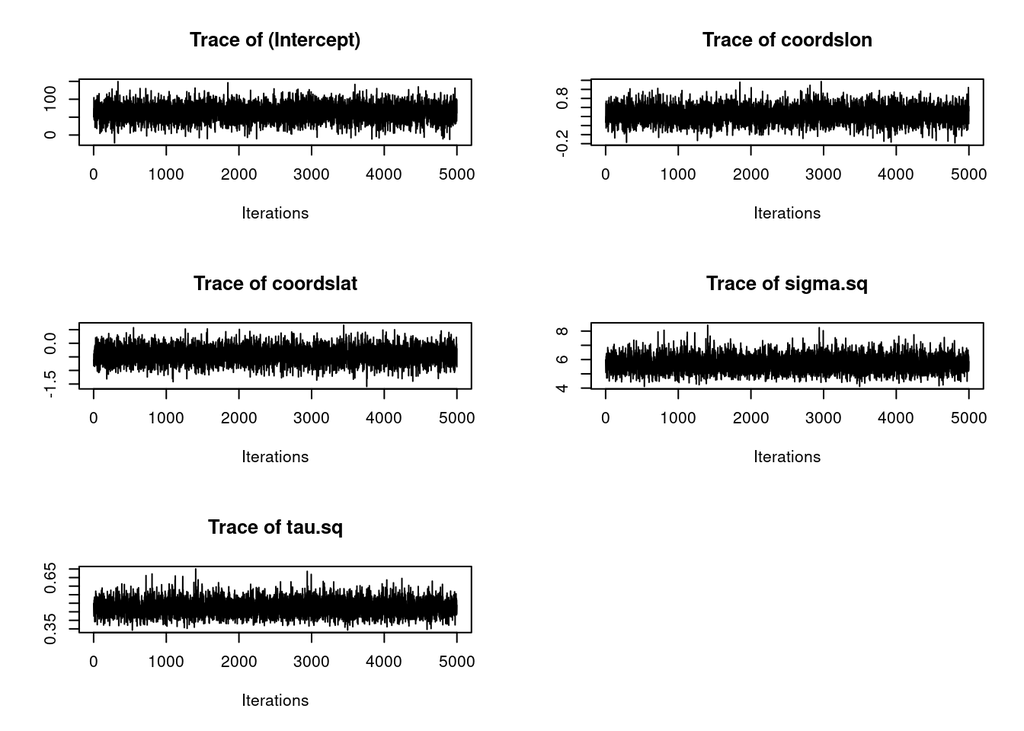

```r
plot(m.exact$p.samples, density = FALSE)
```

Now let’s fit the full Bayesian model using `spLM()`.

```r
cov.model <- "exponential"

starting <- list(phi = 3/(0.5 * d.max), sigma.sq = 5, tau.sq = 5)

tuning <- list(phi = 0.5, sigma.sq = 0.05, tau.sq = 0.05)

priors <- list("beta.Flat", phi.Unif = c(3/d.max, 3/(0.01 * d.max)), sigma.sq.IG = c(2,
    5), tau.sq.IG = c(2, 5))

m.1 <- spLM(temp ~ coords, coords = coords.utm, starting = starting, tuning = tuning,
    priors = priors, cov.model = cov.model, n.samples = n.samples, n.report = 2000)
```

```
----------------------------------------
    General model description
----------------------------------------
Model fit with 213 observations.

Number of covariates 3 (including intercept if specified).

Using the exponential spatial correlation model.

Number of MCMC samples 5000.

Priors and hyperpriors:
    beta flat.
    sigma.sq IG hyperpriors shape=2.00000 and scale=5.00000
    tau.sq IG hyperpriors shape=2.00000 and scale=5.00000
    phi Unif hyperpriors a=0.00356 and b=0.35645
-------------------------------------------------
        Sampling
-------------------------------------------------
Sampled: 2000 of 5000, 40.00%
Report interval Metrop. Acceptance rate: 36.60%
Overall Metrop. Acceptance rate: 36.60%
-------------------------------------------------
Sampled: 4000 of 5000, 80.00%
Report interval Metrop. Acceptance rate: 35.20%
Overall Metrop. Acceptance rate: 35.90%
-------------------------------------------------
```

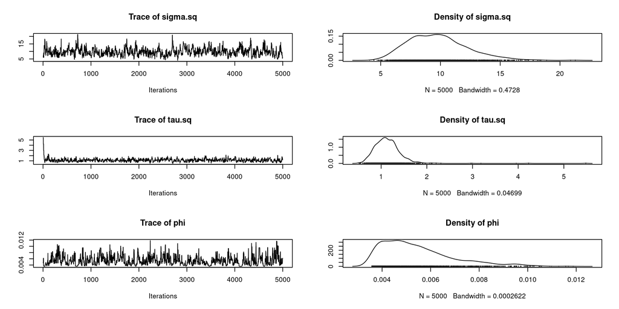

```r
plot(m.1$p.theta.samples)
```

The `spLM()` function only updates the covariance parameters. The regression coefficients $\beta$’s and spatial random effects $w$ are recovered via the `spRecover()` function that performs composition sampling using post burn-in samples.

```r
burn.in <- floor(0.75 * n.samples)

m.1 <- spRecover(m.1, start = burn.in, thin = 2)
```

```
-------------------------------------------------
        Recovering beta and w
-------------------------------------------------
Sampled: 99 of 626, 15.81%
Sampled: 199 of 626, 31.79%
Sampled: 299 of 626, 47.76%
Sampled: 399 of 626, 63.74%
Sampled: 499 of 626, 79.71%
Sampled: 599 of 626, 95.69%
```

```r
round(summary(m.1$p.theta.recover.samples)$quantiles[, c(3, 1, 5)], 3)
```

```
           50%  2.5%  97.5%
sigma.sq 9.719 5.545 15.584
tau.sq   1.101 0.682  1.775
phi      0.005 0.004  0.010
```

```r
round(summary(m.1$p.beta.recover.samples)$quantiles[, c(3, 1, 5)], 3)
```

```
               50%    2.5%   97.5%
(Intercept) 45.498 -43.370 128.072
coordslon    0.249  -0.478   0.956
coordslat   -0.527  -1.669   0.643
```

Now let’s take a look at the estimates of the random effects compared with the non-spatial regression residuals.

```r
quants <- function(x) {
    quantile(x, prob = c(0.5, 0.025, 0.975))
}

## Random effects from bayesGeostatExact()
w.exact.summary <- apply(m.exact$sp.effects, 1, quants)

w.exact.surf <- mba.surf(cbind(coords, w.exact.summary[1, ]), no.X = 200, no.Y = 200,
    extend = TRUE, sp = TRUE)$xyz.est
proj4string(w.exact.surf) <- "+proj=longlat +datum=WGS84"
w.exact.surf <- raster(w.exact.surf)

## Random effects from spLM()
w.m1.summary <- apply(m.1$p.w.recover.samples, 1, quants)

w.m1.surf <- mba.surf(cbind(coords, w.m1.summary[1, ]), no.X = 200, no.Y = 200, extend = TRUE,
    sp = TRUE)$xyz.est
proj4string(w.m1.surf) <- "+proj=longlat +datum=WGS84"
w.m1.surf <- raster(w.m1.surf)

## Make the color ramp
all.values <- c(values(w.exact.surf), values(w.m1.surf), values(resid.surf))
pal <- colorNumeric(blue.red, all.values, na.color = "transparent")

base.map %>%
    addRasterImage(w.exact.surf, colors = pal, opacity = 0.75, group = "bayesGeostatExact") %>%
    addRasterImage(w.m1.surf, colors = pal, opacity = 0.75, group = "spLM m.1") %>%
    addRasterImage(resid.surf, colors = pal, opacity = 0.75, group = "Regression residuals") %>%
    addLegend("bottomright", pal = pal, values = all.values, opacity = 0.75, title = "<center>Random effects &<br>Regression<br>residuals</center>") %>%
    addLayersControl(baseGroup = c("Terrain", "Satellite"), overlayGroups = c("bayesGeostatExact",
        "spLM m.1", "Regression residuals"), options = layersControlOptions(collapsed = FALSE)) %>%
    hideGroup(c("spLM m.1", "Regression residuals"))
```

[interactive chart not shown]

Looks like the spatial random effects are picking up the effect of elevation so let’s just put it in the mean and refit the non-spatial and `spLM()` models.

```r
lm.obj <- lm(temp ~ elev + lon + lat, data = data.frame(coords))
summary(lm.obj)
```

```
Call:
lm(formula = temp ~ elev + lon + lat, data = data.frame(coords))

Residuals:
    Min      1Q  Median      3Q     Max
-4.6706 -0.8541 -0.1308  0.9088  3.5183

Coefficients:
              Estimate Std. Error t value Pr(>|t|)
(Intercept)  7.9372343  5.9584509   1.332    0.184
elev        -0.0059590  0.0002029 -29.374  < 2e-16 ***
lon         -0.1982295  0.0499149  -3.971 9.83e-05 ***
lat         -0.4951096  0.0691068  -7.164 1.32e-11 ***
---
Signif. codes:  0 '***' 0.001 '**' 0.01 '*' 0.05 '.' 0.1 ' ' 1

Residual standard error: 1.412 on 209 degrees of freedom
Multiple R-squared:  0.8415,    Adjusted R-squared:  0.8393
F-statistic:   370 on 3 and 209 DF,  p-value: < 2.2e-16
```

```r
v <- variog(coords = coords.utm, data = resid(lm.obj), uvec = (seq(0, 0.75 * d.max,
    length = 20)))
```

```
variog: computing omnidirectional variogram
```

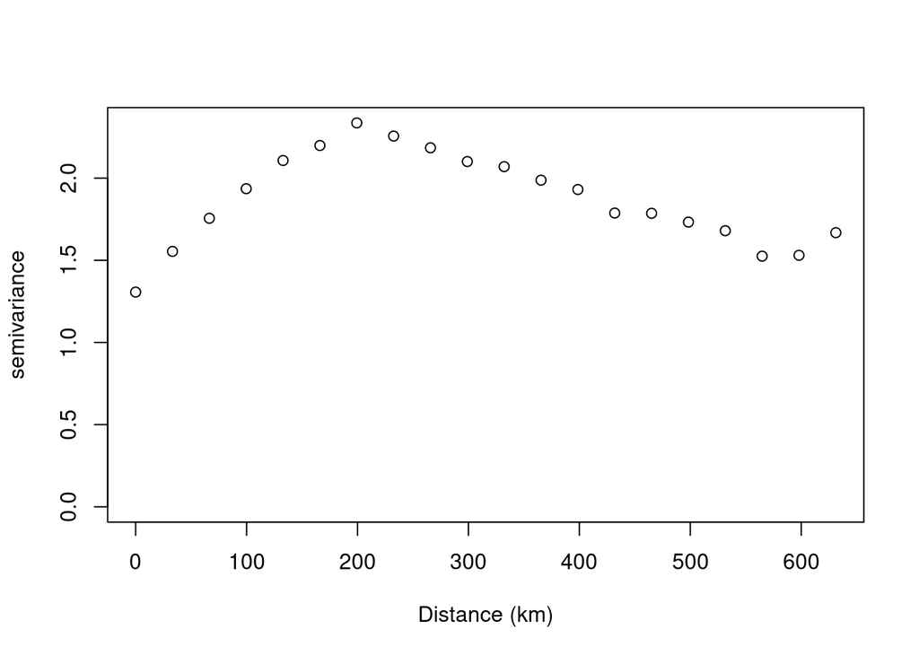

```r
plot(v, xlab = "Distance (km)")
```

Now call `spLM()` with elevation as a covariate after adjusting the variance priors then recover the parameters via the `spRecover()` function.

```r
priors$sigma.sq.IG <- c(2, 1)
priors$tau.sq.IG <- c(2, 1)

m.2 <- spLM(temp ~ elev + coords, coords = coords.utm, starting = starting, tuning = tuning,
    priors = priors, cov.model = cov.model, n.samples = n.samples, n.report = 2000)
```

```
----------------------------------------
    General model description
----------------------------------------
Model fit with 213 observations.

Number of covariates 4 (including intercept if specified).

Using the exponential spatial correlation model.

Number of MCMC samples 5000.

Priors and hyperpriors:
    beta flat.
    sigma.sq IG hyperpriors shape=2.00000 and scale=1.00000
    tau.sq IG hyperpriors shape=2.00000 and scale=1.00000
    phi Unif hyperpriors a=0.00356 and b=0.35645
-------------------------------------------------
        Sampling
-------------------------------------------------
Sampled: 2000 of 5000, 40.00%
Report interval Metrop. Acceptance rate: 38.45%
Overall Metrop. Acceptance rate: 38.45%
-------------------------------------------------
Sampled: 4000 of 5000, 80.00%
Report interval Metrop. Acceptance rate: 35.70%
Overall Metrop. Acceptance rate: 37.08%
-------------------------------------------------
```

```r
m.2 <- spRecover(m.2, start = burn.in, thin = 2)
```

```
-------------------------------------------------
        Recovering beta and w
-------------------------------------------------
Sampled: 99 of 626, 15.81%
Sampled: 199 of 626, 31.79%
Sampled: 299 of 626, 47.76%
Sampled: 399 of 626, 63.74%
Sampled: 499 of 626, 79.71%
Sampled: 599 of 626, 95.69%
```

```r
round(summary(m.2$p.theta.recover.samples)$quantiles[, c(3, 1, 5)], 2)
```

```
          50% 2.5% 97.5%
sigma.sq 1.18 0.69  2.50
tau.sq   0.99 0.60  1.31
phi      0.01 0.00  0.03
```

```r
round(summary(m.2$p.beta.recover.samples)$quantiles[, c(3, 1, 5)], 2)
```

```
              50%   2.5% 97.5%
(Intercept) 10.04 -22.25 34.82
elev        -0.01  -0.01 -0.01
coordslon   -0.19  -0.48  0.05
coordslat   -0.54  -0.90 -0.14
```

```r
w.2.summary <- apply(m.2$p.w.recover.samples, 1, quants)
```

Now let’s take a look at these new random effects compared with those from `m.1`.

```r
w.m2.surf <- mba.surf(cbind(coords, w.2.summary[1, ]), no.X = 200, no.Y = 200, extend = TRUE,
    sp = TRUE)$xyz.est
proj4string(w.m2.surf) <- "+proj=longlat +datum=WGS84"
w.m2.surf <- raster(w.m2.surf)

pal.2 <- colorNumeric(blue.red, values(w.m2.surf), na.color = "transparent")

base.map %>%
    addRasterImage(w.m2.surf, colors = pal.2, opacity = 0.75, group = "spLM m.2") %>%
    addRasterImage(w.m1.surf, colors = pal, opacity = 0.75, group = "spLM m.1") %>%
    addRasterImage(resid.surf, colors = pal, opacity = 0.75, group = "Regression residuals") %>%
    addLegend("bottomleft", pal = pal.2, values = values(w.m2.surf), opacity = 0.75,
        title = "<center>Random effects (m.2)</center>") %>%
    addLegend("bottomright", pal = pal, values = all.values, opacity = 0.75, title = "<center>Random effects (m.1) &<br>Regression<br>residuals</center>") %>%
    addLayersControl(baseGroup = c("Terrain", "Satellite"), overlayGroups = c("spLM m.1",
        "spLM m.2", "Regression residuals"), options = layersControlOptions(collapsed = FALSE)) %>%
    hideGroup(c("spLM m.1", "Regression residuals"))
```

[interactive chart not shown]

###Prediction

Recall, our interest is in creating a temperature surface with associated uncertainty. This is done by sampling from posterior predictive distributions at 17,545 new locations across Colorado. These prediction locations are held in `pred.coords` with spatially coinciding elevation in `pred.elev`. Sampling is done using the `spPredict()` function. Ideally, we would draw more posterior predictive samples, but in the interest of time we take only a small sample to generate the summary statistics and maps. Using more CPU would greatly increase prediction speed.

```r
pred.X <- cbind(1, pred.elev, pred.coords)

m.2.pred <- spPredict(m.2, pred.covars = pred.X, pred.coords = pred.coords, start = burn.in,
    thin = 20, n.report = 10)
```

```
-------------------------------------------------
        Recovering beta
-------------------------------------------------
----------------------------------------
    General model description
----------------------------------------
Model fit with 213 observations.

Prediction at 17545 locations.

Number of covariates 4 (including intercept if specified).

Using the exponential spatial correlation model.

-------------------------------------------------
        Sampling
-------------------------------------------------
Sampled: 10 of 63, 14.29%
Sampled: 20 of 63, 30.16%
Sampled: 30 of 63, 46.03%
Sampled: 40 of 63, 61.90%
Sampled: 50 of 63, 77.78%
Sampled: 60 of 63, 93.65%
```

```r
y.p.summary <- apply(m.2.pred$p.y.predictive.samples, 1, quants)

y.p.width <- y.p.summary[3, ] - y.p.summary[2, ]
```

The summaries of the posterior predictive distributions can be mapped or exported for use in a GIS system.

```r
y.median.surf <- rasterFromXYZ(cbind(pred.coords, y.p.summary[1, ]))
proj4string(y.median.surf) <- "+proj=longlat +datum=WGS84"
pal.1 <- colorNumeric(blue.red, c(values(y.median.surf), temp), na.color = "transparent")

y.width.surf <- rasterFromXYZ(cbind(pred.coords, y.p.width))
proj4string(y.width.surf) <- "+proj=longlat +datum=WGS84"
pal.2 <- colorNumeric(blue.red, values(y.width.surf), na.color = "transparent")

base.map %>%
    addRasterImage(y.median.surf, colors = pal.1, opacity = 0.9, group = "Predicted temperature") %>%
    addRasterImage(y.width.surf, colors = pal.2, opacity = 0.9, group = "Prediction 95% CI width") %>%
    addCircleMarkers(lng = coords[, 1], lat = coords[, 2], col = pal.1(temp), fillOpacity = 0.9,
        stroke = FALSE, radius = 3, popup = paste("Mean min temp:", round(temp, 1)),
        group = "Stations") %>%
    addLegend("bottomleft", pal = pal.1, values = values(y.median.surf), opacity = 0.9,
        title = "<center>Predicted<br>temperature C</center>") %>%
    addLegend("bottomright", pal = pal.2, values = values(y.width.surf), opacity = 0.9,
        title = "<center>Prediction<br>95% CI width</center>") %>%
    addLayersControl(baseGroup = c("Terrain", "Satellite"), overlayGroups = c("Predicted temperature",
        "Prediction 95% CI width", "Stations"), options = layersControlOptions(collapsed = FALSE)) %>%
    hideGroup(c("Prediction 95% CI width", "Stations"))
```

[interactive chart not shown]

### Model comparison

Here we take a very brief look at some of the model assessment tools in `spBayes`. Specifically, we compare the non-spatial and spatial regression models using the deviance information criterion (DIC), where lower values of DIC suggest improved fit.

```r
lm.ref <- bayesLMRef(lm.obj, 500)

spDiag(lm.ref)$DIC
```

```
-------------------------------------------------
        Calculating scores
-------------------------------------------------
```

```
                value
bar.D       361.13150
D.bar.Omega 356.09917
pD            5.03233
DIC         366.16383
```

```r
spDiag(m.2)$DIC
```

```
-------------------------------------------------
        Calculating scores
-------------------------------------------------
```

```
                value
bar.D       204.98381
D.bar.Omega 130.20929
pD           74.77452
DIC         279.75833
```